# Prompt for Project 2

Create a new Github page with a presentation on the concepts of Locally Weighted Regression and Random Forest.

Apply the regression methods to real data sets, such as "Cars" or "Boston Housing Data" where you consider only one input variable (the weight of the car for the "Cars" data set and the number of rooms for the "Boston Hausing" data). The output varable is the mileage for the "Cars" data set and "cmedv" or the median price for the housing data.

For each method and data set report the crossvalidated mean square error and determine which method is achieving the better results.

In this paper you should also include theoretical considerations, examples of Python coding and plots.

The final results should be clearly stated.

# Comparison between Locally Weighted Regression and Random Forest

### Locally Weighted Regression (Loess or Lowess):

Locally weighted regression, or loess, is a non-parametric procedure for fitting a regression surface to data through multivariate smoothing: The dependent variable is smoothed as a function of the independent variables in a moving fashion analogous to how a moving average is computed for a time series [1](https://doi.org/2289282). It performs regression step by step around a point of interest using only the data that are 'local' to that point, which means the few nearest poitns [2](http://www.cs.cmu.edu/afs/cs/project/jair/pub/volume4/cohn96a-html/node7.html).

### Random Forest

Random forest is a meta estimator that fits a number of classifying decision trees on various sub-samples of the dataset and uses averaging to improve the predictive accuracy and control over-fitting [3](https://scikit-learn.org/stable/modules/generated/sklearn.ensemble.RandomForestRegressor.html?highlight=randomforestregressor#sklearn.ensemble.RandomForestRegressor).

# See the difference between the two through an example:

## First things first, import the libraries and functions needed

```python
import numpy as np
import pandas as pd
import matplotlib.pyplot as plt
from scipy.interpolate import interp1d
from sklearn.ensemble import RandomForestRegressor
from sklearn.model_selection import KFold
from sklearn.metrics import mean_squared_error as mse
from sklearn.model_selection import train_test_split as tts
from sklearn.preprocessing import StandardScaler
from scipy import linalg
```

## Examine the data

Dataset 'cars' will be used for the example. Within the dataset, the WGT or the weight of the car will be used to predict the MPG or miles per gas of each cars.

```python
data = pd.read_csv('cars.csv')
```

```python
data.head()
```

|  | MPG | CYL | ENG | WGT |
| --- | --- | --- | --- | --- |
| 0 | 18.0 | 8 | 307.0 | 3504 |
| 1 | 15.0 | 8 | 350.0 | 3693 |
| 2 | 18.0 | 8 | 318.0 | 3436 |
| 3 | 16.0 | 8 | 304.0 | 3433 |
| 4 | 17.0 | 8 | 302.0 | 3449 |

After examining the the dataset, extract the value from each respected column as x and y.

```python
x = data['WGT'].values
y = data['MPG'].values
```

Scatter plot is drawn here just to show how the data looks like.

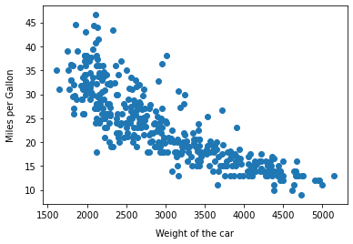

```python
plt.scatter(x,y)
plt.ylabel('Miles per Gallon', labelpad = 10)
plt.xlabel('Weight of the car', labelpad = 10)
plt.show()
```